# tsibbletalk: Crosstalk for Time Series in Shiny

Author

Dror Berel

# Learning goals

By the end of this lesson, you should be able to:

- explain why a `tsibble` is a better object than a plain data frame for interactive time series work
- identify the `index`, `key`, and measured variables in a time series dataset
- use `tsibbletalk::as_shared_tsibble()` to create Crosstalk-linked time series views
- combine linked Plotly displays with a Shiny module for interactive time slicing

# Why `tsibble`?

A plain data frame can store time series data, but it does not tell R which column is time, which columns identify the observational unit, or whether rows form regular temporal sequences. Those details are usually left as informal knowledge in the analyst’s head.

A `tsibble` makes those details explicit:

- the `index` is the time variable, such as date, month, quarter, or timestamp
- the `key` identifies one time series inside a larger panel
- measured variables store the values observed over time
- the object can carry interval information and supports time-aware verbs such as `filter_index()`, `fill_gaps()`, and `index_by()`

This matters in Shiny because time series apps usually need to preserve two kinds of identity at once:

- temporal identity: what period is this observation from?
- series identity: which region, sensor, product, patient, or portfolio does this observation belong to?

`tsibble` gives those concepts names in the data object itself. That makes the app code easier to reason about and reduces the chance that a plot, table, feature summary, or filter accidentally groups by the wrong columns.

# Why `tsibbletalk`?

The `crosstalk` package links HTML widgets through shared keys. That is useful, but time series data has a special shape: one logical item is often not one row. A single series may have many rows because it is observed repeatedly through time.

The `tsibbletalk` package builds on that idea. Its GitHub README says a tsibble consists of an index, key, and measured variables, and that linked brushing by key can speed up exploratory time series graphics. The package adds a shared key to a tsibble so linked views can “crosstalk” across plots with or without Shiny.

In practice, `tsibbletalk` helps you:

- link a tree of series keys to a time series plot
- link a time series plot to a feature plot, such as trend strength against seasonal strength
- preserve the tsibble’s key/index semantics while using Plotly and Crosstalk-style interaction
- add a Shiny time-slicing module with `tsibbleWrapUI()` and `tsibbleWrapServer()`

Source: https://github.com/earowang/tsibbletalk

# Packages

Install the packages if needed. `tsibbletalk` is installed from GitHub.

```r
install.packages(c(
  "shiny",
  "bslib",
  "dplyr",
  "ggplot2",
  "plotly",
  "feasts",
  "tsibble",
  "tsibbledata",
  "remotes"
))

remotes::install_github("earowang/tsibbletalk")
```

Load the packages:

```r
library(shiny)
library(bslib)
library(dplyr)
library(ggplot2)
library(plotly)
library(feasts)
library(tsibble)
library(tsibbledata)
library(tsibbletalk) # pak::pak("earowang/tsibbletalk")
```

# The data

This lesson uses the `tourism` data. It is already a panel of time series: trips are measured by quarter, and each series is identified by geography and travel purpose.

```r
tourism

key_vars(tourism)
index_var(tourism)
```

The important point is not just that `tourism` has a date-like column. The object knows which column is the time index and which columns form the series key. That is the structure `tsibbletalk` uses for linked time series exploration.

# Rendered plot examples

The complete Shiny app later in the tutorial uses `tourism` because it matches the `tsibbletalk` examples. This rendered HTML also includes a few evaluated plots so the page has visible output without launching a Shiny app.

These plots use `aus_retail`, another tsibble dataset from `tsibbledata`. It is monthly, keyed by state and industry, and works well for demonstrating the same ideas: time index, series key, artificial missing observations, and feature-based annotations.

```r
library(dplyr)
library(ggplot2)
library(tsibble)
library(tsibbledata)
library(feasts)

retail_demo <- aus_retail |>
  filter(
    State %in% c("Victoria", "New South Wales"),
    Industry == "Cafes, restaurants and takeaway food services"
  ) |>
  mutate(
    Month_date = as.Date(Month),
    Month_label = as.character(Month)
  )
```

## Example 1: regular monthly series

This first plot shows two monthly retail turnover series. The tsibble index is `Month`, and the key is the combination of `State` and `Industry`.

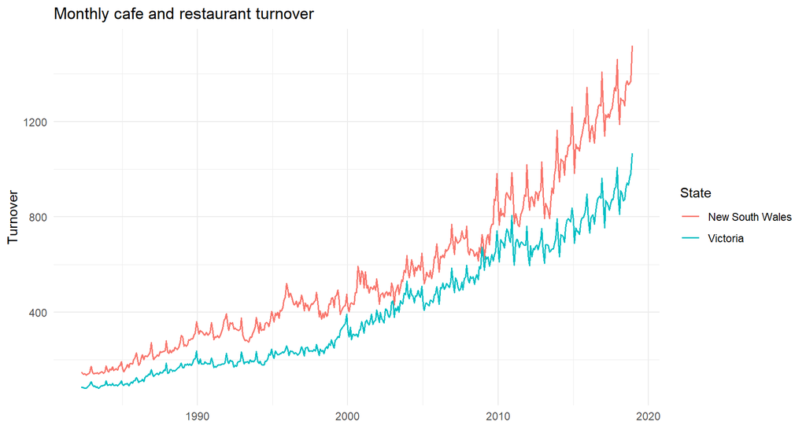

```r
retail_demo |>
  ggplot(aes(x = Month_date, y = Turnover, colour = State)) +
  geom_line(linewidth = 0.6) +
  labs(
    title = "Monthly cafe and restaurant turnover",
    x = NULL,
    y = "Turnover"
  ) +
  theme_minimal()
```

## Example 2: flagged time-window gaps

The source series is regular, so this example removes a few known months to create teaching gaps. The red points mark observations where the gap from the previous observation in the same series is not one month.

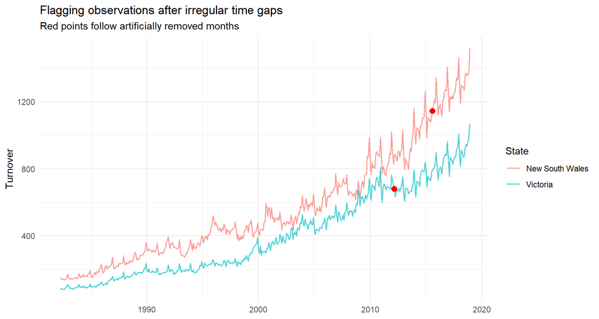

```r
missing_months <- tibble::tribble(
  ~State, ~Industry, ~Month,
  "Victoria",
  "Cafes, restaurants and takeaway food services",
  tsibble::yearmonth("2012 Jan"),
  "Victoria",
  "Cafes, restaurants and takeaway food services",
  tsibble::yearmonth("2012 Feb"),
  "New South Wales",
  "Cafes, restaurants and takeaway food services",
  tsibble::yearmonth("2015 Jul")
)

retail_gap_demo <- retail_demo |>
  anti_join(
    missing_months,
    by = c("State", "Industry", "Month")
  ) |>
  group_by_key() |>
  arrange(Month, .by_group = TRUE) |>
  mutate(
    time_window_months = round(
      as.numeric(Month_date - lag(Month_date)) / 30.4375
    ),
    time_window_flag = !is.na(time_window_months) &
      time_window_months != 1
  ) |>
  ungroup()

retail_gap_demo |>
  ggplot(aes(x = Month_date, y = Turnover, colour = State)) +
  geom_line(linewidth = 0.6, alpha = 0.7) +
  geom_point(
    data = retail_gap_demo |> filter(time_window_flag),
    aes(
      x = Month_date,
      y = Turnover
    ),
    colour = "red",
    size = 2.7
  ) +
  labs(
    title = "Flagging observations after irregular time gaps",
    subtitle = "Red points follow artificially removed months",
    x = NULL,
    y = "Turnover"
  ) +
  theme_minimal()
```

## Example 3: level-shift feature markers

This plot uses `feasts::shift_level_max()` to identify the largest level shift in each series. The red points show where the returned `shift_level_index` maps back onto the ordered tsibble rows.

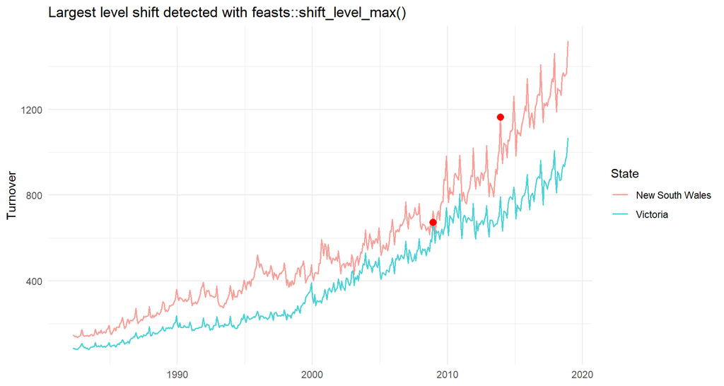

```r
retail_shift_base <- retail_demo |>
  group_by_key() |>
  arrange(Month, .by_group = TRUE) |>
  mutate(.series_row = row_number()) |>
  ungroup()

shift_features <- retail_shift_base |>
  features(
    Turnover,
    shift_level_max,
    .period = 12
  )

retail_shift_plot <- retail_shift_base |>
  left_join(
    shift_features,
    by = c("State", "Industry")
  ) |>
  mutate(
    largest_shift_point = .series_row == shift_level_index
  )

retail_shift_plot |>
  ggplot(aes(x = Month_date, y = Turnover, colour = State)) +
  geom_line(linewidth = 0.6, alpha = 0.7) +
  geom_point(
    data = retail_shift_plot |> filter(largest_shift_point),
    aes(
      x = Month_date,
      y = Turnover
    ),
    colour = "red",
    size = 2.7
  ) +
  labs(
    title = "Largest level shift detected with feasts::shift_level_max()",
    x = NULL,
    y = "Turnover"
  ) +
  theme_minimal()
```

# Create a shared tsibble

`as_shared_tsibble()` converts a tsibble into a shared tsibble that can participate in Crosstalk-style linked views.

```r
tourism_shared <- tourism |>
  as_shared_tsibble(spec = (State / Region) * Purpose)
```

The `spec` argument describes the key structure. In this example:

- `State / Region` says regions are nested within states
- `* Purpose` says each location is crossed with travel purpose

That structure is useful for navigation. A user can select a state, region, or purpose and have the linked displays respond through the shared series key.

# Linked views without Shiny

This first example can work in a regular HTML document. The linked interaction happens in the browser.

```r
tourism_shared <- tourism |>
  as_shared_tsibble(spec = (State / Region) * Purpose)

key_tree <- plotly_key_tree(
  tourism_shared,
  height = 800,
  width = 500
)

series_plot <- tourism_shared |>
  ggplot(aes(x = Quarter, y = Trips)) +
  geom_line(aes(group = Region), alpha = 0.45) +
  facet_wrap(vars(Purpose), scales = "free_y") +
  labs(
    title = "Quarterly tourism trips",
    x = NULL,
    y = "Trips"
  )

tourism_features <- tourism_shared |>
  features(Trips, feat_stl)

feature_plot <- tourism_features |>
  ggplot(aes(
    x = trend_strength,
    y = seasonal_strength_year
  )) +
  geom_point(aes(group = Region), alpha = 0.7) +
  labs(
    title = "Series features",
    x = "Trend strength",
    y = "Seasonal strength"
  )

subplot(
  key_tree,
  subplot(
    ggplotly(series_plot, tooltip = c("Region", "Purpose")),
    ggplotly(feature_plot, tooltip = c("Region", "Purpose")),
    nrows = 2,
    shareX = FALSE
  ),
  widths = c(0.35, 0.65)
) |>
  highlight(dynamic = TRUE)
```

There are three linked views:

- the key tree helps navigate the hierarchy of available series
- the line plot shows the time path
- the feature plot summarizes each series as a point

The same series key connects them. Selecting a series in one display can highlight the matching series in the other displays. This is the main reason to use `tsibbletalk` instead of manually wrapping a plain data frame in `crosstalk::SharedData`: the unit of interaction is a time series key, not an accidental row number.

# Detect level shifts with `feasts`

The `feasts` package is designed to work naturally with tsibble workflows. One useful feature function is `shift_level_max()`, which finds the largest mean shift between two consecutive sliding windows in a univariate time series.

This is slightly different from shifting or realigning the raw data. `shift_level_max()` does not move observations. It returns two feature values:

- the size of the largest level shift
- the index position where that largest shift occurs

That makes it useful in interactive time series apps because the app can surface the series with the largest structural changes, annotate the time plot, or let users select series based on level-shift behavior.

```r
tourism_shift_features <- tourism |>
  features(
    Trips,
    shift_level_max,
    .period = 4
  )

tourism_shift_features
```

The result is one row per tsibble key. For the `tourism` data, the key is the combination of `Region`, `State`, and `Purpose`. The feature columns describe the largest change in average `Trips` between adjacent windows and the position of that change within the series.

```r
largest_level_shifts <- tourism_shift_features |>
  arrange(desc(shift_level_max)) |>
  slice_head(n = 10)

largest_level_shifts
```

This can be connected back to the time series plot. The next example joins the feature output back to the original tsibble and creates a simple flag for the time point where the largest level shift occurred.

```r
tourism_with_shift <- tourism |>
  group_by_key() |>
  mutate(.series_row = row_number()) |>
  ungroup() |>
  left_join(
    tourism_shift_features,
    by = c("Region", "State", "Purpose")
  ) |>
  mutate(
    largest_shift_point = .series_row == shift_level_index
  )

tourism_with_shift |>
  filter(largest_shift_point)
```

In a Shiny application, this gives you a useful pattern:

- compute `shift_level_max()` after the user filters the tsibble
- rank series by the largest level shift
- show the selected series in a linked `tsibbletalk` plot
- draw a marker where `.series_row` equals `shift_level_index`

Here is a small plotting pattern:

```r
selected_series <- tourism_with_shift |>
  filter(
    State == "Victoria",
    Purpose == "Holiday"
  )

selected_series |>
  ggplot(aes(x = Quarter, y = Trips, group = Region)) +
  geom_line(alpha = 0.45) +
  geom_point(
    data = selected_series |> filter(largest_shift_point),
    colour = "red",
    size = 2
  ) +
  facet_wrap(vars(Region), scales = "free_y") +
  labs(
    title = "Largest detected level shift by tourism series",
    x = NULL,
    y = "Trips"
  )
```

This section also shows why the tsibble structure matters. The feature calculation is applied per series key, and the returned index position can be mapped back to the tsibble’s ordered time index. With a plain data frame, you would need to manage that grouping and index logic manually.

# Add Shiny for time slicing

The previous example is client-side linked exploration. Shiny becomes useful when the app needs server-side behavior: changing time windows, recomputing summaries, downloading data, or preparing a filtered object for a model.

`tsibbletalk` includes a Shiny module pair:

- `tsibbleWrapUI(id)`
- `tsibbleWrapServer(id, plot, period = ...)`

The module wraps a time series plot with controls for slicing and dicing the time index.

```r
pedestrian_plot <- pedestrian |>
  fill_gaps() |>
  filter_index(~ "2015") |>
  ggplot(aes(x = Date_Time, y = Count, colour = Sensor)) +
  geom_line(linewidth = 0.2) +
  facet_wrap(vars(Sensor), scales = "free_y") +
  theme(legend.position = "none") +
  labs(
    title = "Pedestrian counts by sensor",
    x = NULL,
    y = "Count"
  )

ui <- fluidPage(
  titlePanel("Interactive time slicing with tsibbletalk"),
  tsibbleWrapUI("pedestrian")
)

server <- function(input, output, session) {
  tsibbleWrapServer(
    id = "pedestrian",
    plot = pedestrian_plot,
    period = "1 day"
  )
}

shinyApp(ui, server)
```

This is different from a generic Shiny slider over row numbers. The module is built for a tsibble plot, where the index has temporal meaning. The user is slicing time, not arbitrary table positions.

# Complete Shiny app

This app combines ordinary Shiny controls with `tsibbletalk` linked views. The sidebar filters the dataset on the server. The main panel uses a shared tsibble to link the key tree, time series plot, and feature plot.

## Time window length flagging

The app also calculates the time window length between each observation and the previous observation in the same time series. For the quarterly `tourism` data, this gap is measured in months.

The original `tourism` toy data is intentionally regular: each series is observed once per quarter, so nearly every consecutive gap is three months. That is good for teaching tsibble structure, but it does not produce many useful examples for gap flagging. To make the behavior visible in the tutorial, the app creates a small teaching copy of the data with a few observations removed. Those removals create artificial six-month gaps that the flagging controls can detect.

Two sidebar inputs control the accepted range:

- minimum allowed time window length
- maximum allowed time window length

Any observation with a gap outside that range is flagged and drawn as a red point in the time series plot. This is useful for spotting missing periods, irregularly spaced observations, or unexpected jumps in the time index after filtering.

```r
library(shiny)
library(bslib)
library(dplyr)
library(ggplot2)
library(plotly)
library(feasts)
library(tsibble)
library(tsibbledata)
library(tsibbletalk)

tourism_demo <- tourism |>
  anti_join(
    tibble::tribble(
      ~Region, ~State, ~Purpose, ~Quarter,
      "Ballarat", "Victoria", "Business", tsibble::yearquarter("2010 Q2"),
      "Bendigo Loddon", "Victoria", "Holiday", tsibble::yearquarter("2012 Q3"),
      "Blue Mountains", "New South Wales", "Visiting", tsibble::yearquarter("2014 Q1")
    ),
    by = c("Region", "State", "Purpose", "Quarter")
  )

ui <- page_sidebar(
  title = "tsibbletalk tourism explorer",
  theme = bs_theme(version = 5, bootswatch = "flatly"),
  sidebar = sidebar(
    width = 320,
    selectInput(
      inputId = "states",
      label = "States",
      choices = sort(unique(tourism_demo$State)),
      selected = c("Victoria", "New South Wales"),
      multiple = TRUE
    ),
    selectInput(
      inputId = "purposes",
      label = "Travel purpose",
      choices = sort(unique(tourism_demo$Purpose)),
      selected = sort(unique(tourism_demo$Purpose)),
      multiple = TRUE
    ),
    sliderInput(
      inputId = "year_range",
      label = "Years",
      min = 1998,
      max = 2016,
      value = c(2005, 2016),
      sep = ""
    ),
    numericInput(
      inputId = "min_gap_months",
      label = "Minimum time window length, in months",
      value = 3,
      min = 1,
      step = 1
    ),
    numericInput(
      inputId = "max_gap_months",
      label = "Maximum time window length, in months",
      value = 3,
      min = 1,
      step = 1
    )
  ),
  layout_columns(
    col_widths = c(4, 8),
    card(
      card_header("Series navigation"),
      plotlyOutput("key_tree", height = 700)
    ),
    card(
      card_header("Linked time series views"),
      plotlyOutput("linked_views", height = 700)
    )
  )
)

server <- function(input, output, session) {
  filtered_tourism <- reactive({
    req(
      input$states,
      input$purposes,
      input$year_range,
      input$min_gap_months,
      input$max_gap_months
    )
    validate(
      need(
        input$min_gap_months <= input$max_gap_months,
        "The minimum time window length must be less than or equal to the maximum."
      )
    )

    tourism_demo |>
      mutate(
        Quarter_date = as.Date(Quarter),
        Quarter_label = as.character(Quarter),
        Quarter_year = as.integer(format(Quarter_date, "%Y"))
      ) |>
      filter(
        State %in% input$states,
        Purpose %in% input$purposes,
        Quarter_year >= input$year_range[1],
        Quarter_year <= input$year_range[2]
      ) |>
      group_by_key() |>
      arrange(Quarter, .by_group = TRUE) |>
      mutate(
        time_window_months = round(
          as.numeric(Quarter_date - lag(Quarter_date)) / 30.4375
        ),
        time_window_flag = !is.na(time_window_months) &
          (
            time_window_months < input$min_gap_months |
              time_window_months > input$max_gap_months
          )
      )
  })

  shared_tourism <- reactive({
    filtered_tourism() |>
      as_shared_tsibble(spec = (State / Region) * Purpose)
  })

  output$key_tree <- renderPlotly({
    plotly_key_tree(shared_tourism(), height = 700)
  })

  output$linked_views <- renderPlotly({
    flagged_points <- shared_tourism() |>
      filter(time_window_flag)

    series_plot <- shared_tourism() |>
      ggplot(aes(x = Quarter_date, y = Trips)) +
      geom_line(aes(group = Region), alpha = 0.5) +
      geom_point(
        data = flagged_points,
        aes(
          text = paste(
            "Region:", Region,
            "<br>Purpose:", Purpose,
            "<br>Quarter:", Quarter_label,
            "<br>Time window:", time_window_months, "months"
          )
        ),
        colour = "red",
        size = 2.2
      ) +
      facet_wrap(vars(Purpose), scales = "free_y") +
      labs(
        x = NULL,
        y = "Trips",
        caption = "Red points mark observations where the gap from the previous observation is outside the allowed range."
      )

    feature_data <- shared_tourism() |>
      features(Trips, feat_stl)

    feature_plot <- feature_data |>
      ggplot(aes(
        x = trend_strength,
        y = seasonal_strength_year
      )) +
      geom_point(aes(group = Region), alpha = 0.75) +
      labs(
        x = "Trend strength",
        y = "Seasonal strength"
      )

    subplot(
      ggplotly(
        series_plot,
        tooltip = c("Region", "Purpose", "time_window_months", "text")
      ),
      ggplotly(feature_plot, tooltip = c("Region", "Purpose")),
      nrows = 2,
      shareX = FALSE
    ) |>
      highlight(dynamic = TRUE)
  })
}

shinyApp(ui, server)
```

# How the app works

- Shiny filters rebuild the tsibble on the server.
- Shiny gap controls calculate the time window length between consecutive observations within each series key.
- `tsibbletalk` preserves the shared time series key for linked views in the browser.

That separation is useful. Shiny owns the expensive or stateful work: filtering the source data, recomputing features, and deciding which data is available. `tsibbletalk` owns the linked visual exploration: when a series is selected in one view, the other views know which series should respond.

The time window calculation happens after the user filters the data. Within each tsibble key, the app sorts by `Quarter`, compares each observation’s `Quarter_date` to the previous observation’s `Quarter_date`, and stores the gap as `time_window_months`. `Quarter` remains the tsibble index; `Quarter_date`, `Quarter_label`, and `Quarter_year` are helper columns for Shiny filtering, Plotly display, and gap calculation. Observations are flagged when the gap is below the minimum or above the maximum selected in the sidebar. The first observation in each series has no previous timestamp, so it is not flagged.

The app uses `tourism_demo`, not the untouched `tourism` object. This is deliberate. The source toy data is very regular, so the default allowed range of exactly three months would usually flag nothing. Removing a few known observations creates predictable six-month gaps and lets the workshop demonstrate what the flagging logic is supposed to catch. In a real project, the same calculation would usually run on the original incoming data to reveal naturally missing or irregular observations.

# Practical guidance

Use a `tsibble` when:

- each observational unit is measured repeatedly through time
- the app needs to distinguish a time index from ordinary numeric columns
- the app needs to group by series keys consistently
- you plan to compute time series features, fill gaps, aggregate by time, or filter by index

Use `tsibbletalk` when:

- multiple time series graphics should be linked by series identity
- the data has nested or crossed key variables
- users need to move between overview, individual series, and feature summaries
- Shiny controls should change the time series dataset while linked browser-side exploration remains available

For small one-off charts, a plain data frame plus Plotly may be enough. For panel time series apps, `tsibble` and `tsibbletalk` make the important structure explicit, which usually leads to clearer app code and better user interaction.

# Common pitfalls

## Treating rows as series

In regular Crosstalk examples, one row is often one plotted item. In time series data, one series usually spans many rows. Use the tsibble key as the linked identity.

## Hiding the time index

Do not convert dates or quarters to labels too early. Keep the index as a real temporal variable so tsibble verbs and time-aware controls can work correctly.

## Forgetting the key structure

For hierarchical panels, pass a meaningful `spec` to `as_shared_tsibble()`. The key tree is only useful when the hierarchy matches the domain.

## Expecting Crosstalk to replace Shiny

Crosstalk-style linking is excellent for browser-side interaction. Shiny is still needed for server-side computation, downloads, model fitting, database queries, and outputs that depend on reactive state.

# Exercises

1. Change the tourism app to start with only one selected state.
2. Add a `selectInput()` for `Region` after the state has been chosen.
3. Replace `feat_stl` with another feature set from `feasts`.
4. Use `shift_level_max()` to rank regions by their largest level shift.
5. Add a download button that writes the Shiny-filtered tsibble to CSV.
6. Build a second app using `pedestrian` and `tsibbleWrapUI()`/`tsibbleWrapServer()`.

# Additional resources

- `tsibbletalk` GitHub repository: https://github.com/earowang/tsibbletalk
- `shift_level_max()` reference: https://feasts.tidyverts.org/reference/shift_level_max.html
- Crosstalk documentation: https://rstudio.github.io/crosstalk/
- Tsibble paper: https://arxiv.org/abs/1901.10257